```python
import os
from sklearn.model_selection import StratifiedShuffleSplit
import tensorflow as tf
import numpy as np
import pandas as pd
from tensorflow.keras.models import Sequential
from keras.layers.core import Dense,Activation
import tensorflow_datasets as tfds
import soundfile as sf
from tensorflow.keras.callbacks import EarlyStopping
from tensorflow.keras.layers import Conv1D, Dense, MaxPooling1D, Flatten,Conv2D,MaxPooling2D,GRU, LSTM,Input, Concatenate, LeakyReLU
from tensorflow.keras.layers import BatchNormalization, Dropout
from matplotlib import pyplot as plt
from tensorflow.keras.layers.experimental.preprocessing import Rescaling
from sklearn.model_selection import train_test_split
from tensorflow.keras.models import Model
from tensorflow.keras.models import load_model,save_model
from tensorflow.keras.models import Sequential
import tensorflow.keras.layers as layers
from tensorflow.keras.layers import Dense
from tensorflow import keras
import numpy as np
import librosa
import os
import pickle
import itertools
from keras.layers import Layer
from keras import backend as K
import tensorflow.keras.backend as K
import librosa
from tensorflow.keras.utils import Sequence
from tensorflow.keras.activations import sigmoid
from tensorflow.keras.metrics import BinaryAccuracy
import pickle
import random
from itertools import combinations
import matplotlib.pyplot as plt
from sklearn.preprocessing import MinMaxScaler,OneHotEncoder
```

# Part 1

**Loading the data**

```python
data = tfds.load('mnist', split='train', as_supervised=True)
```

```python
data_test = tfds.load('mnist', split='test', as_supervised=True)
```

```python
data
```

```
<PrefetchDataset shapes: ((28, 28, 1), ()), types: (tf.uint8, tf.int64)>
```

```python
train_data = [(example.numpy(), label.numpy()) for example, label in data]
```

**Converting to individual patches**

```python
get_patches = lambda x, y: (tf.reshape(
    tf.image.extract_patches(
        images=tf.expand_dims(x, 0),
        sizes=[1, 7, 7, 1],
        strides=[1, 7, 7, 1],
        rates=[1, 1, 1, 1],
        padding='VALID'), (16, 7, 7, 1)), y)
```

```python
data = data.map(get_patches)
```

```python
data_test = data_test.map(get_patches)
```

```python
data
```

```
<MapDataset shapes: ((16, 7, 7, 1), ()), types: (tf.uint8, tf.int64)>
```

**Printing the original image patch**

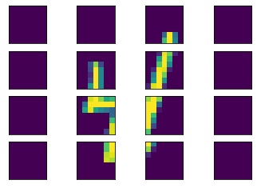

```python
fig = plt.figure()
plt.subplots_adjust(wspace=.1, hspace=.2)
images, labels = next(iter(data))
#print('OG:',images.shape)
for index, image in enumerate(images):
    #print(index)
    ax = plt.subplot(4, 4, index + 1)
    ax.set_xticks([])
    ax.set_yticks([])
    #print(image.shape)
    ax.imshow(tf.reshape(image,[7,7]))
plt.show()
```

**Data conversion and adding the patches together, thus making a array of patches**

```python
xtrain_patch = [example.numpy().reshape([16,49]) for example, label in data]
```

```python
ytrain_patch = [label.numpy() for example, label in data]
```

```python
xtest_patch = [example.numpy().reshape([16,49]) for example, label in data_test]
ytest_patch = [label.numpy() for example, label in data_test]
```

```python
len(xtrain_patch),len(ytrain_patch)
```

```
(60000, 60000)
```

```python
len(xtest_patch),len(ytest_patch)
```

```
(10000, 10000)
```

```python
ytrain_patch[0]
```

```
4
```

```python
xtrain_patch[0].shape, ytrain_patch[1].shape
```

```
((16, 49), ())
```

```python
xtest_patch[0].shape, ytest_patch[1].shape
```

```
((16, 49), ())
```

```python
for i in range(0,len(xtrain_patch)):
  xtrain_patch[i] = xtrain_patch[i]/255

for i in range(0,len(xtest_patch)):
  xtest_patch[i] = xtest_patch[i]/255
```

```python
xtrain_patch[0].shape
```

```
(16, 49)
```

```python
xtrain_patch = np.stack(xtrain_patch)
ytrain_path = np.stack(ytrain_patch)
xtest_patch = np.stack(xtest_patch)
ytest_patch = np.stack(ytest_patch)
```

```python
xtrain_patch.shape
```

```
(60000, 16, 49)
```

```python
xtrain_patch[:,1:16,:].shape
```

```
(60000, 15, 49)
```

**Defining the model**

```python
model = Sequential()
model.add(Input(shape=(None,49)))
model.add(LSTM(64, return_sequences=True,activation='tanh'))
model.add(layers.Dropout(rate = 0.1))
model.add(Dense(49, activation='relu',kernel_initializer=tf.keras.initializers.HeNormal()))
```

```python
model.compile(loss='mse',optimizer = tf.keras.optimizers.Adam(learning_rate=0.001))
```

**Running the model**

```python
callback = tf.keras.callbacks.EarlyStopping(monitor='val_loss', patience=3)
model.fit(xtrain_patch[:,0:15,:], xtrain_patch[:,1:16,:], epochs=100, callbacks=callback,batch_size=256,validation_data=[xtest_patch[:,0:15,:],xtest_patch[:,1:16,:]])
```

```
<keras.callbacks.History at 0x7fc4f54226d0>
```

**Predicting the model and combining the upper half and predicted half by doing LSTM**

```python
y_pred = xtest_patch[0,0:8,:].reshape(1,8,49)
l = model.predict(y_pred)
patch = l[:,7,:].reshape(1,1,49)
```

```python
l.shape
```

```
(1, 8, 49)
```

```python
patch = l
m=7
for i in range(7):
  l = model.predict(patch)
  print(l.shape)
  patch = np.hstack((patch, l[:,m,:].reshape(1,1,49)))
  m=m+1
```

```
(1, 8, 49)
(1, 9, 49)
(1, 10, 49)
(1, 11, 49)
(1, 12, 49)
(1, 13, 49)
(1, 14, 49)
```

```python
patch.shape
```

```
(1, 15, 49)
```

```python
patch = patch[:,7:,:]
```

```python
patch.shape
```

```
(1, 8, 49)
```

```python
images = np.concatenate((y_pred[0],patch[0])).reshape(1,16,49)
images = images[0].reshape(16,7,7)
```

**Predicted Image**

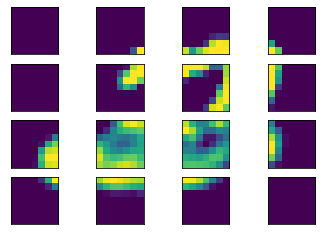

```python
fig = plt.figure()
plt.subplots_adjust(wspace=.1, hspace=.2)
for index, image in enumerate(images):
    ax = plt.subplot(4, 4, index + 1)
    ax.set_xticks([])
    ax.set_yticks([])
    #print(image.shape)
    ax.imshow(tf.reshape(image,[7,7]))
plt.show()
```

**Real Image**

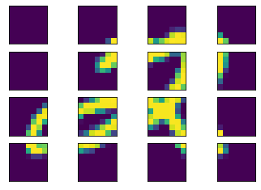

```python
test_og_img = xtest_patch[0,:,:].reshape(16,7,7)
fig = plt.figure()
plt.subplots_adjust(wspace=.1, hspace=.2)
for index, image in enumerate(test_og_img):
    ax = plt.subplot(4, 4, index + 1)
    ax.set_xticks([])
    ax.set_yticks([])
    #print(image.shape)
    ax.imshow(tf.reshape(image,[7,7]))
plt.show()
```

```python
rows = tf.split(images,28//7,axis=0)
rows = [tf.concat(tf.unstack(x),axis=1) for x in rows]
reconstructed = tf.concat(rows,axis=0)
```

```python
reconstructed.shape
```

```
TensorShape([28, 28])
```

```python
xtest_ls=[]
for i in range(0,10):
  ytest_ind = np.where(ytest_patch == i)
  xtest_ls.append(xtest_patch[ytest_ind[0][0:10]])
```

**Function to combine the predicted images for each class and display 10x10 grid**

```python
def patchpred(img):
  y_pred = img[0:8,:].reshape(1,8,49)
  l = model.predict(y_pred)
  patch = l[:,7,:].reshape(1,1,49)
  patch = l
  m=7
  for i in range(7):
    l = model.predict(patch)
    #print(l.shape)
    patch = np.hstack((patch, l[:,m,:].reshape(1,1,49)))
    m=m+1
  patch = patch[:,7:,:]
  images = np.concatenate((y_pred[0],patch[0])).reshape(1,16,49)
  images = images[0].reshape(16,7,7)
  rows = tf.split(images,28//7,axis=0)
  rows = [tf.concat(tf.unstack(x),axis=1) for x in rows]
  reconstructed = tf.concat(rows,axis=0)
  return reconstructed

def pred(img):
  img = img.reshape(16,7,7)
  rows = tf.split(img,28//7,axis=0)
  rows = [tf.concat(tf.unstack(x),axis=1) for x in rows]
  reconstructed = tf.concat(rows,axis=0)
  return reconstructed
```

```python
final_reconstructed = []
for i in range(0,10):
  for j in range(0,10):
    final_reconstructed.append(patchpred(xtest_ls[i][j]))
```

```python
final_original = []
for i in range(0,10):
  for j in range(0,10):
    final_original.append(pred(xtest_ls[i][j]))
```

```python
final_reconstructed[0].shape
```

```
TensorShape([28, 28])
```

```python
len(final_original)
```

```
100
```

```python
final_reconstructed[0].shape
```

```
TensorShape([28, 28])
```

**Construted Grid**

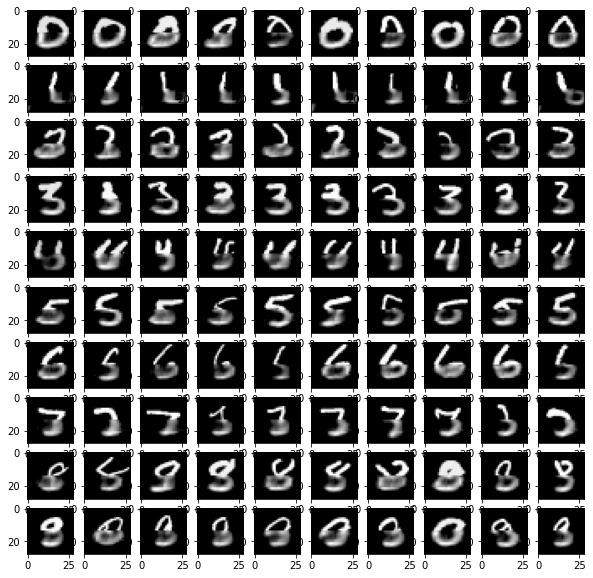

```python
fig, ax = plt.subplots(10,10,figsize=(10,10))
k=0
for i in range(10):
    for j in range(10):
        ax[i][j].imshow(final_reconstructed[k], cmap='gray')
        k+=1
```

**Original Grid**

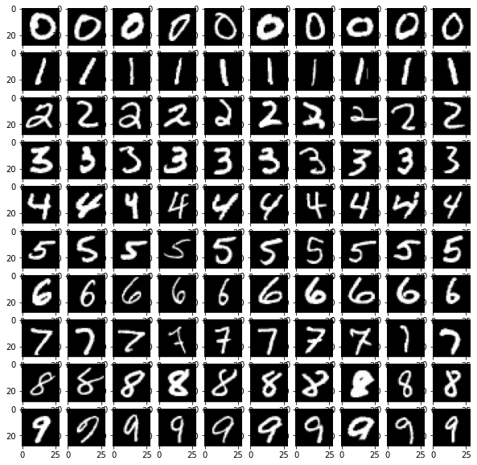

```python
fig, ax = plt.subplots(10,10,figsize=(10,10))
k=0
for i in range(10):
    for j in range(10):
        ax[i][j].imshow(final_original[k], cmap='gray')
        k+=1
```

# Part 2

**Importing the files**

```python
with open('hw5_tr7.pkl', 'rb') as f:
    train_data = pickle.load(f)
with open('hw5_te7.pkl', 'rb') as f:
    test_data = pickle.load(f)
```

```python
train_data.shape
```

```
(6265, 28, 28)
```

```python
test_data.shape
```

```
(1028, 28, 28)
```

**Converting them to 4 d shape**

```python
train_data = train_data.reshape([6265,28,28,1])
test_data = test_data.reshape([1028,28,28,1])
```

#### Ref: https://keras.io/examples/generative/vae/

**Create the Sampling Layer**

```python
class Sampling_Layer(layers.Layer):
    """Uses (z_mean, z_log_var) to sample z, the vector encoding a digit."""

    def call(self, inputs):
        z_mean, z_log_var = inputs
        batch = tf.shape(z_mean)[0]
        dim = tf.shape(z_mean)[1]
        epsilon = tf.keras.backend.random_normal(shape=(batch, dim))
        return z_mean + tf.exp(0.5 * z_log_var) * epsilon
```

**Creating the Encoder**

```python
latent_dim = 3

encoder_inputs = tf.keras.Input(shape=(28, 28, 1))
x = layers.Conv2D(32, 3, activation="relu", strides=2, padding="same")(encoder_inputs)
x = layers.Conv2D(64, 3, activation="relu", strides=2, padding="same")(x)
x = layers.Flatten()(x)
x = layers.Dense(16, activation="relu")(x)
z_mean = layers.Dense(latent_dim, name="z_mean")(x)
z_log_var = layers.Dense(latent_dim, name="z_log_var")(x)
z = Sampling_Layer()([z_mean, z_log_var])
encoder = tf.keras.Model(encoder_inputs, [z_mean, z_log_var, z], name="encoder")
encoder.summary()
```

```
Model: "encoder"
__________________________________________________________________________________________________
 Layer (type)                   Output Shape         Param #     Connected to
==================================================================================================
 input_1 (InputLayer)           [(None, 28, 28, 1)]  0           []

 conv2d (Conv2D)                (None, 14, 14, 32)   320         ['input_1[0][0]']

 conv2d_1 (Conv2D)              (None, 7, 7, 64)     18496       ['conv2d[0][0]']

 flatten (Flatten)              (None, 3136)         0           ['conv2d_1[0][0]']

 dense (Dense)                  (None, 16)           50192       ['flatten[0][0]']

 z_mean (Dense)                 (None, 3)            51          ['dense[0][0]']

 z_log_var (Dense)              (None, 3)            51          ['dense[0][0]']

 sampling__layer (Sampling_Laye  (None, 3)           0           ['z_mean[0][0]',
 r)                                                               'z_log_var[0][0]']

==================================================================================================
Total params: 69,110
Trainable params: 69,110
Non-trainable params: 0
__________________________________________________________________________________________________
```

**Build the decoder**

```python
latent_inputs = tf.keras.Input(shape=(latent_dim,))
x = layers.Dense(7 * 7 * 64, activation="relu")(latent_inputs)
x = layers.Reshape((7, 7, 64))(x)
x = layers.Conv2DTranspose(64, 3, activation="relu", strides=2, padding="same")(x)
x = layers.Conv2DTranspose(32, 3, activation="relu", strides=2, padding="same")(x)
decoder_outputs = layers.Conv2DTranspose(1, 3, activation="sigmoid", padding="same")(x)
decoder = tf.keras.Model(latent_inputs, decoder_outputs, name="decoder")
decoder.summary()
```

```
Model: "decoder"
_________________________________________________________________
 Layer (type)                Output Shape              Param #
=================================================================
 input_2 (InputLayer)        [(None, 3)]               0

 dense_1 (Dense)             (None, 3136)              12544

 reshape (Reshape)           (None, 7, 7, 64)          0

 conv2d_transpose (Conv2DTra  (None, 14, 14, 64)       36928
 nspose)

 conv2d_transpose_1 (Conv2DT  (None, 28, 28, 32)       18464
 ranspose)

 conv2d_transpose_2 (Conv2DT  (None, 28, 28, 1)        289
 ranspose)

=================================================================
Total params: 68,225
Trainable params: 68,225
Non-trainable params: 0
_________________________________________________________________
```

**Creating the VAE as a combination of Encoder Decoder along with the reconstruction loss and Kullback–Leibler divergence term loss**

```python
class VAE(tf.keras.Model):
    def __init__(self, encoder, decoder, **kwargs):
        super(VAE, self).__init__(**kwargs)
        self.encoder = encoder
        self.decoder = decoder
        self.total_loss_tracker = tf.keras.metrics.Mean(name="total_loss")
        self.reconstruction_loss_tracker = tf.keras.metrics.Mean(
            name="reconstruction_loss"
        )
        self.kl_loss_tracker = tf.keras.metrics.Mean(name="kl_loss")

    @property
    def metrics(self):
        return [
            self.total_loss_tracker,
            self.reconstruction_loss_tracker,
            self.kl_loss_tracker,
        ]

    def train_step(self, data):
        with tf.GradientTape() as tape:
            z_mean, z_log_var, z = self.encoder(data)
            reconstruction = self.decoder(z)
            reconstruction_loss = tf.reduce_mean(
                tf.reduce_sum(
                    keras.losses.binary_crossentropy(data, reconstruction), axis=(1, 2)
                )
            )
            kl_loss = -0.5 * (1 + z_log_var - tf.square(z_mean) - tf.exp(z_log_var))
            kl_loss = tf.reduce_mean(tf.reduce_sum(kl_loss, axis=1))
            total_loss = reconstruction_loss + kl_loss
        grads = tape.gradient(total_loss, self.trainable_weights)
        self.optimizer.apply_gradients(zip(grads, self.trainable_weights))
        self.total_loss_tracker.update_state(total_loss)
        self.reconstruction_loss_tracker.update_state(reconstruction_loss)
        self.kl_loss_tracker.update_state(kl_loss)
        return {
            "loss": self.total_loss_tracker.result(),
            "reconstruction_loss": self.reconstruction_loss_tracker.result(),
            "kl_loss": self.kl_loss_tracker.result(),
        }
```

```python
mnist_digits = np.concatenate([train_data, test_data], axis=0)
```

```python
mnist_digits.shape
```

```
(7293, 28, 28, 1)
```

**Running the model**

```python
vae = VAE(encoder, decoder)
vae.compile(optimizer=tf.keras.optimizers.Adam())
vae.fit(mnist_digits, epochs=30, batch_size=128)
```

```
<keras.callbacks.History at 0x7f354674aa50>
```

**Testing**

```python
#function which keeps 2 dimesions constant and changes the 3rd one

def plot_latent_space(vae,non_constant_dim,n=15, figsize=15):
    digit_size = 28
    scale = 5.0
    figure = np.zeros((n,digit_size , digit_size))
    # linearly spaced coordinates corresponding to the 2D plot
    # of digit classes in the latent space
    if non_constant_dim == 1:
      grid_x = np.linspace(-scale, scale, n)
      grid_y = np.repeat(np.random.normal(loc = 0, scale = 1, size = (1)),15)
      grid_z = np.repeat(np.random.normal(loc = 0, scale = 1, size = (1)),15)
    elif non_constant_dim == 2:
      grid_y = np.linspace(-scale, scale, n)
      grid_x = np.repeat(np.random.normal(loc = 0, scale = 1, size = (1)),15)
      grid_z = np.repeat(np.random.normal(loc = 0, scale = 1, size = (1)),15)
    elif non_constant_dim == 3:
      grid_z = np.linspace(-scale, scale, n)
      grid_x = np.repeat(np.random.normal(loc = 0, scale = 1, size = (1)),15)
      grid_y = np.repeat(np.random.normal(loc = 0, scale = 1, size = (1)),15)

    for k in range(0,n):
      z_sample = np.array([[grid_x[k],grid_y[k],grid_z[k]]])
      #print(z_sample.shape)
      x_decoded = vae.decoder.predict(z_sample)
      digit = x_decoded[0].reshape(digit_size, digit_size)
      #print(digit.shape)
      figure[k] = digit
    print(figure.shape)
    return figure
```

```python
figure1 = plot_latent_space(vae,1)
figure2 = plot_latent_space(vae,2)
figure3 = plot_latent_space(vae,3)
```

```
(15, 28, 28)
(15, 28, 28)
(15, 28, 28)
```

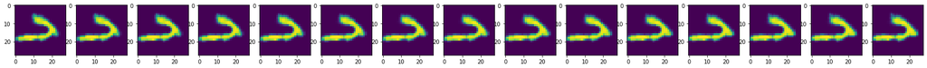

```python
fig, ax = plt.subplots(1,15,figsize=(30,30))
k=0
for i in range(15):
    ax[i].imshow(figure1[i])
```

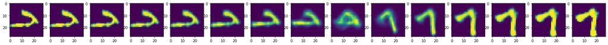

```python
fig, ax = plt.subplots(1,15,figsize=(30,30))
k=0
for i in range(15):
    ax[i].imshow(figure2[i])
```

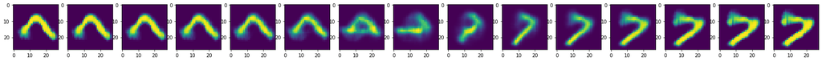

```python
fig, ax = plt.subplots(1,15,figsize=(30,30))
k=0
for i in range(15):
    ax[i].imshow(figure3[i])
```

**In the above cell you can find the pattern for the changing dimension**

# Part 3

Ref: https://keras.io/examples/generative/conditional_gan/

**Importing the data and preprocessing**

```python
(xtrain, ytrain), (xtest, ytest) = tf.keras.datasets.mnist.load_data()
xtrain = xtrain/255.
xtest = xtest/255.
```

```python
xtrain.shape
```

```
(60000, 28, 28)
```

```python
xtrain_flat=[]
for i in range(len(xtrain)):
  xtrain_flat.append(xtrain[i].flatten())
xtrain_flat = np.array(xtrain_flat)
```

```python
xtrain_flat.shape
```

```
(60000, 784)
```

```python
ytrain = ytrain.reshape(-1,1)
encoder=OneHotEncoder()
encoder.fit(ytrain)
label = encoder.transform(ytrain).toarray()
ytrain=label
```

```python
ytrain.shape
```

```
(60000, 10)
```

```python
scaler=MinMaxScaler(feature_range=(-1,1))
xtrain_flat=scaler.fit_transform(xtrain_flat)
xtrain_flat.shape,ytrain.shape
```

```
((60000, 784), (60000, 10))
```

```python
xtest_flat=[]
for i in range(len(xtest)):
  xtest_flat.append(xtest[i].flatten())
xtest_flat = np.array(xtest_flat)
```

```python
xtest_flat.shape
```

```
(10000, 784)
```

```python
ytest = ytest.reshape(-1,1)
encoder=OneHotEncoder()
encoder.fit(ytest)
label = encoder.transform(ytest).toarray()
ytest=label
```

```python
ytest.shape
```

```
(10000, 10)
```

```python
xtest_flat=scaler.fit_transform(xtest_flat)
xtest_flat.shape,ytest.shape
```

```
((10000, 784), (10000, 10))
```

**Defining the generator and discriminator model and fixing the inputs**

```python
ndim = 100
classes = 10
noise_channel = Input(shape=(ndim,))
onehot_channel = Input(shape=(classes,))
```

```python
generator_model=Sequential()
generator_model.add(Dense(units=200,kernel_initializer='HeNormal',activation='relu'))
generator_model.add(BatchNormalization(momentum=0.5))
generator_model.add(Dense(units=400,kernel_initializer='HeNormal',activation='relu'))
generator_model.add(BatchNormalization(momentum=0.5))
generator_model.add(Dense(units=784,activation='tanh',kernel_initializer='HeNormal'))
model_input=Concatenate(axis=1)([noise_channel,onehot_channel])
image=generator_model(model_input)
generator_model = Model([noise_channel,onehot_channel],image,name='generator_model')
generator_model.summary()
```

```
Model: "generator_model"
__________________________________________________________________________________________________
 Layer (type)                   Output Shape         Param #     Connected to
==================================================================================================
 input_23 (InputLayer)          [(None, 100)]        0           []

 input_24 (InputLayer)          [(None, 10)]         0           []

 concatenate_21 (Concatenate)   (None, 110)          0           ['input_23[0][0]',
                                                                  'input_24[0][0]']

 sequential_21 (Sequential)     (None, 784)          419384      ['concatenate_21[0][0]']

==================================================================================================
Total params: 419,384
Trainable params: 418,184
Non-trainable params: 1,200
__________________________________________________________________________________________________
```

```python
discriminator_model=Sequential()
discriminator_model.add(Dense(units=400,kernel_initializer='HeNormal'))
discriminator_model.add(LeakyReLU(alpha=0.2))
discriminator_model.add(Dropout(0.2))

discriminator_model.add(Dense(units=200,kernel_initializer='HeNormal'))
discriminator_model.add(LeakyReLU(alpha=0.2))
discriminator_model.add(Dropout(0.1))

discriminator_model.add(Dense(units=100,kernel_initializer='HeNormal'))
discriminator_model.add(LeakyReLU(alpha=0.2))
discriminator_model.add(Dropout(0.1))

discriminator_model.add(Dense(units=1,activation='sigmoid',kernel_initializer='GlorotNormal'))
input_image=Input(shape=(784,))
label=Input(shape=(classes,))

model = Concatenate(axis=1)([input_image, label])
pred = discriminator_model(model)
discriminator_model =  Model([input_image,label], pred, name='discriminator_model')

discriminator_model.summary()
```

```
Model: "discriminator_model"
__________________________________________________________________________________________________
 Layer (type)                   Output Shape         Param #     Connected to
==================================================================================================
 input_29 (InputLayer)          [(None, 784)]        0           []

 input_30 (InputLayer)          [(None, 10)]         0           []

 concatenate_22 (Concatenate)   (None, 794)          0           ['input_29[0][0]',
                                                                  'input_30[0][0]']

 sequential_22 (Sequential)     (None, 1)            418401      ['concatenate_22[0][0]']

==================================================================================================
Total params: 418,401
Trainable params: 418,401
Non-trainable params: 0
__________________________________________________________________________________________________
```

```python
discriminator_model.compile(loss = 'binary_crossentropy', optimizer = tf.keras.optimizers.Adam(0.0001, 0.5), metrics = ['binary_accuracy'])
```

**Creating the conditional GAN model combined**

```python
discriminator_model.trainable = False
img = generator_model([noise_channel,onehot_channel])
output = discriminator_model([img,onehot_channel])
conditional_gan = Model([noise_channel, onehot_channel], output)
conditional_gan.compile(loss= 'binary_crossentropy', optimizer = tf.keras.optimizers.Adam(0.0001, 0.5))
```

```python
epochs = 150
batch_size = 256
real_img = np.ones(shape = (batch_size, 1))
fake_img = np.zeros(shape = (batch_size,1))
```

**Running the model with inputs and losses of discriminator and generator. Discriminator loss is mean of real and fake images loss. Generator loss is the loss on the fake image generated. Eventually fake image accuracy and real image accuracy should reach that point where it achieves nash equilibrium**

```python
losses=[]
dis_losses=[]
real_ls=[]
fake_ls=[]
for epoch in range(epochs):
    for i in range(0,len(xtrain_flat),batch_size):
        discriminator_model.trainable = True
        image, labels = xtrain_flat[i:i+batch_size,:], ytrain[i:i+batch_size,:]
        real_loss ,real_accuracy = discriminator_model.train_on_batch([image, labels], real_img[:len(labels),:])
        z = np.random.normal(0,1,size = (batch_size, ndim))
        label_fake = np.eye(classes)[np.random.choice(classes, batch_size,replace=True)]
        generated_image = generator_model.predict([z,label_fake])
        fake_loss, fake_accuracy = discriminator_model.train_on_batch([generated_image, label_fake], fake_img[:len(label_fake),:])
        discriminator_loss = (real_loss + fake_loss) / 2
        discriminator_model.trainable = False
        z = np.random.normal(0,1,size = (batch_size, ndim))
        labels = np.eye(classes)[np.random.choice(classes, batch_size, replace=True)]
        generator_loss = conditional_gan.train_on_batch([z,labels], real_img)


    epoch_real_accuracy = real_accuracy
    epoch_fake_accuracy = fake_accuracy
    epoch_generator_loss = generator_loss
    epoch_discriminator_losses = discriminator_loss
    print(f"Epoch: {epoch} Disc. Loss: {epoch_discriminator_losses} Real Img Accuracy: {epoch_real_accuracy} Fake Img Accuracy: {epoch_fake_accuracy} Gen Loss- {epoch_generator_loss}")

    real_ls.append(epoch_real_accuracy)
    fake_ls.append(epoch_fake_accuracy)
    losses.append(epoch_generator_loss)
    dis_losses.append(epoch_discriminator_losses)
```

```
Epoch: 0 Disc. Loss: 0.0037016357528045774 Real Img Accuracy: 1.0 Fake Img Accuracy: 1.0 Gen Loss- 8.73928451538086
Epoch: 1 Disc. Loss: 0.09505538828670979 Real Img Accuracy: 1.0 Fake Img Accuracy: 0.9375 Gen Loss- 8.009577751159668
Epoch: 2 Disc. Loss: 0.375414177775383 Real Img Accuracy: 0.9270833134651184 Fake Img Accuracy: 0.7421875 Gen Loss- 4.940443992614746
Epoch: 3 Disc. Loss: 0.6184445917606354 Real Img Accuracy: 0.6145833134651184 Fake Img Accuracy: 0.61328125 Gen Loss- 1.880810260772705
Epoch: 4 Disc. Loss: 0.6591524481773376 Real Img Accuracy: 0.5520833134651184 Fake Img Accuracy: 0.59765625 Gen Loss- 1.291728138923645
Epoch: 5 Disc. Loss: 0.6257472634315491 Real Img Accuracy: 0.5208333134651184 Fake Img Accuracy: 0.73828125 Gen Loss- 1.0890156030654907
Epoch: 6 Disc. Loss: 0.5625486075878143 Real Img Accuracy: 0.6770833134651184 Fake Img Accuracy: 0.7421875 Gen Loss- 1.0866694450378418
Epoch: 7 Disc. Loss: 0.47605322301387787 Real Img Accuracy: 0.8541666865348816 Fake Img Accuracy: 0.78125 Gen Loss- 1.059286117553711
Epoch: 8 Disc. Loss: 0.6143627166748047 Real Img Accuracy: 0.625 Fake Img Accuracy: 0.6796875 Gen Loss- 1.003807544708252
Epoch: 9 Disc. Loss: 0.49423564970493317 Real Img Accuracy: 0.8229166865348816 Fake Img Accuracy: 0.77734375 Gen Loss- 1.2132500410079956
Epoch: 10 Disc. Loss: 0.5675056874752045 Real Img Accuracy: 0.6979166865348816 Fake Img Accuracy: 0.7578125 Gen Loss- 1.147023320198059
Epoch: 11 Disc. Loss: 0.5400265753269196 Real Img Accuracy: 0.7083333134651184 Fake Img Accuracy: 0.69140625 Gen Loss- 1.2058602571487427
Epoch: 12 Disc. Loss: 0.5354543626308441 Real Img Accuracy: 0.7291666865348816 Fake Img Accuracy: 0.734375 Gen Loss- 1.3678832054138184
Epoch: 13 Disc. Loss: 0.5801654607057571 Real Img Accuracy: 0.5833333134651184 Fake Img Accuracy: 0.78125 Gen Loss- 1.352471947669983
Epoch: 14 Disc. Loss: 0.4983508139848709 Real Img Accuracy: 0.6875 Fake Img Accuracy: 0.8203125 Gen Loss- 1.3834571838378906
Epoch: 15 Disc. Loss: 0.4563734382390976 Real Img Accuracy: 0.7395833134651184 Fake Img Accuracy: 0.7890625 Gen Loss- 1.5494740009307861
Epoch: 16 Disc. Loss: 0.5290652513504028 Real Img Accuracy: 0.6145833134651184 Fake Img Accuracy: 0.796875 Gen Loss- 1.4726312160491943
Epoch: 17 Disc. Loss: 0.4936230182647705 Real Img Accuracy: 0.7083333134651184 Fake Img Accuracy: 0.77734375 Gen Loss- 1.4003664255142212
Epoch: 18 Disc. Loss: 0.4575757831335068 Real Img Accuracy: 0.78125 Fake Img Accuracy: 0.80859375 Gen Loss- 1.4634641408920288
Epoch: 19 Disc. Loss: 0.4784698784351349 Real Img Accuracy: 0.78125 Fake Img Accuracy: 0.77734375 Gen Loss- 1.5335187911987305
Epoch: 20 Disc. Loss: 0.42990459501743317 Real Img Accuracy: 0.7604166865348816 Fake Img Accuracy: 0.85546875 Gen Loss- 1.395592212677002
Epoch: 21 Disc. Loss: 0.4640353322029114 Real Img Accuracy: 0.8125 Fake Img Accuracy: 0.75390625 Gen Loss- 1.5573947429656982
Epoch: 22 Disc. Loss: 0.44798849523067474 Real Img Accuracy: 0.8229166865348816 Fake Img Accuracy: 0.7890625 Gen Loss- 1.422096610069275
Epoch: 23 Disc. Loss: 0.4407447576522827 Real Img Accuracy: 0.7395833134651184 Fake Img Accuracy: 0.8125 Gen Loss- 1.4372963905334473
Epoch: 24 Disc. Loss: 0.4635986238718033 Real Img Accuracy: 0.7916666865348816 Fake Img Accuracy: 0.80078125 Gen Loss- 1.402488350868225
Epoch: 25 Disc. Loss: 0.4831327199935913 Real Img Accuracy: 0.6979166865348816 Fake Img Accuracy: 0.77734375 Gen Loss- 1.4678661823272705
Epoch: 26 Disc. Loss: 0.4125346541404724 Real Img Accuracy: 0.8229166865348816 Fake Img Accuracy: 0.7734375 Gen Loss- 1.4861369132995605
Epoch: 27 Disc. Loss: 0.43815454840660095 Real Img Accuracy: 0.7916666865348816 Fake Img Accuracy: 0.77734375 Gen Loss- 1.4649511575698853
Epoch: 28 Disc. Loss: 0.4471674710512161 Real Img Accuracy: 0.8020833134651184 Fake Img Accuracy: 0.8046875 Gen Loss- 1.3745241165161133
Epoch: 29 Disc. Loss: 0.4691282957792282 Real Img Accuracy: 0.7916666865348816 Fake Img Accuracy: 0.78125 Gen Loss- 1.3603804111480713
Epoch: 30 Disc. Loss: 0.41224604845046997 Real Img Accuracy: 0.8333333134651184 Fake Img Accuracy: 0.79296875 Gen Loss- 1.3690112829208374
Epoch: 31 Disc. Loss: 0.442846342921257 Real Img Accuracy: 0.8645833134651184 Fake Img Accuracy: 0.73828125 Gen Loss- 1.2957996129989624
Epoch: 32 Disc. Loss: 0.45674391090869904 Real Img Accuracy: 0.8333333134651184 Fake Img Accuracy: 0.75390625 Gen Loss- 1.2546483278274536
Epoch: 33 Disc. Loss: 0.4390573054552078 Real Img Accuracy: 0.8229166865348816 Fake Img Accuracy: 0.80078125 Gen Loss- 1.3157185316085815
Epoch: 34 Disc. Loss: 0.43850329518318176 Real Img Accuracy: 0.8333333134651184 Fake Img Accuracy: 0.7421875 Gen Loss- 1.274121642112732
Epoch: 35 Disc. Loss: 0.45669369399547577 Real Img Accuracy: 0.84375 Fake Img Accuracy: 0.7421875 Gen Loss- 1.2566488981246948
Epoch: 36 Disc. Loss: 0.49518342316150665 Real Img Accuracy: 0.78125 Fake Img Accuracy: 0.73046875 Gen Loss- 1.1901271343231201
Epoch: 37 Disc. Loss: 0.44158174097537994 Real Img Accuracy: 0.78125 Fake Img Accuracy: 0.74609375 Gen Loss- 1.2233693599700928
Epoch: 38 Disc. Loss: 0.4976963996887207 Real Img Accuracy: 0.8020833134651184 Fake Img Accuracy: 0.69140625 Gen Loss- 1.3006672859191895
Epoch: 39 Disc. Loss: 0.49452878534793854 Real Img Accuracy: 0.8125 Fake Img Accuracy: 0.7109375 Gen Loss- 1.2840919494628906
```

[output cut: 95 more lines]

```
Epoch: 135 Disc. Loss: 0.5594352781772614 Real Img Accuracy: 0.7395833134651184 Fake Img Accuracy: 0.71484375 Gen Loss- 0.8989782929420471
Epoch: 136 Disc. Loss: 0.5680819749832153 Real Img Accuracy: 0.7604166865348816 Fake Img Accuracy: 0.65234375 Gen Loss- 0.8952230215072632
Epoch: 137 Disc. Loss: 0.5380394011735916 Real Img Accuracy: 0.7291666865348816 Fake Img Accuracy: 0.71875 Gen Loss- 0.9154254794120789
Epoch: 138 Disc. Loss: 0.5584716200828552 Real Img Accuracy: 0.7604166865348816 Fake Img Accuracy: 0.6796875 Gen Loss- 0.8869373798370361
Epoch: 139 Disc. Loss: 0.5872006416320801 Real Img Accuracy: 0.78125 Fake Img Accuracy: 0.640625 Gen Loss- 0.8707427382469177
Epoch: 140 Disc. Loss: 0.551913395524025 Real Img Accuracy: 0.8020833134651184 Fake Img Accuracy: 0.6875 Gen Loss- 0.8970410823822021
Epoch: 141 Disc. Loss: 0.5694070309400558 Real Img Accuracy: 0.7604166865348816 Fake Img Accuracy: 0.64453125 Gen Loss- 0.8818696141242981
Epoch: 142 Disc. Loss: 0.5686551928520203 Real Img Accuracy: 0.71875 Fake Img Accuracy: 0.65234375 Gen Loss- 0.8746795654296875
Epoch: 143 Disc. Loss: 0.5682120621204376 Real Img Accuracy: 0.7291666865348816 Fake Img Accuracy: 0.6796875 Gen Loss- 0.8906411528587341
Epoch: 144 Disc. Loss: 0.5722512900829315 Real Img Accuracy: 0.7604166865348816 Fake Img Accuracy: 0.6328125 Gen Loss- 0.8700675964355469
Epoch: 145 Disc. Loss: 0.5396052151918411 Real Img Accuracy: 0.7083333134651184 Fake Img Accuracy: 0.69140625 Gen Loss- 0.9014668464660645
Epoch: 146 Disc. Loss: 0.5551959276199341 Real Img Accuracy: 0.8125 Fake Img Accuracy: 0.625 Gen Loss- 0.883071780204773
Epoch: 147 Disc. Loss: 0.5716815739870071 Real Img Accuracy: 0.7395833134651184 Fake Img Accuracy: 0.64453125 Gen Loss- 0.8664718866348267
Epoch: 148 Disc. Loss: 0.550666019320488 Real Img Accuracy: 0.78125 Fake Img Accuracy: 0.67578125 Gen Loss- 0.8879141807556152
Epoch: 149 Disc. Loss: 0.5765074342489243 Real Img Accuracy: 0.7604166865348816 Fake Img Accuracy: 0.640625 Gen Loss- 0.8931612968444824
```

**Plot of Real vs Fake Accuracy for Discriminator**

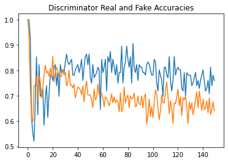

```python
plt.plot(real_ls,label='Real Images Accuracy');
plt.plot(fake_ls,label='Fake Images Accuracy');
plt.title("Discriminator Real and Fake Accuracies")
```

**Grid Plot for the Fake Images the Generator Generates**

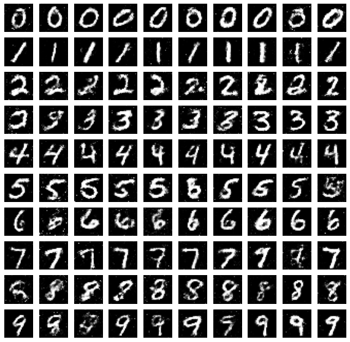

```python
m, n = 10,10
noise = np.random.normal(0,1,(m*n, ndim))

labels=[]
for x in np.eye(classes):
  for i in range(10):
    labels.append(x.tolist())
labels = np.array(labels)
image = generator_model.predict([noise,labels])
image = 0.5 * image + 0.5
fig, ax = plt.subplots(m,n, figsize = (10,10))
cnt = 0
for i in range(m):
    for j in range(n):
        ax[i,j].imshow(image[cnt,:].reshape((28,28)),cmap = 'gray')
        ax[i,j].axis('off')
        cnt+=1
```

# Part 4

**Data Preprocessing**

```python
(xtrain, ytrain), (xtest, ytest) = tf.keras.datasets.mnist.load_data()
xtrain = xtrain/255.
xtest = xtest/255.
```

```python
xtrain_flat=[]
for i in range(len(xtrain)):
  xtrain_flat.append(xtrain[i].flatten())
xtrain_flat = np.array(xtrain_flat)
```

```python
ytrain = ytrain.reshape(-1,1)
encoder=OneHotEncoder()
encoder.fit(ytrain)
label = encoder.transform(ytrain).toarray()
ytrain=label
```

```python
scaler=MinMaxScaler(feature_range=(-1,1))
xtrain_flat=scaler.fit_transform(xtrain_flat)
xtrain_flat.shape,ytrain.shape
```

```
((60000, 784), (60000, 10))
```

```python
xtest_flat=[]
for i in range(len(xtest)):
  xtest_flat.append(xtest[i].flatten())
xtest_flat = np.array(xtest_flat)
```

```python
ytest = ytest.reshape(-1,1)
encoder=OneHotEncoder()
encoder.fit(ytest)
label = encoder.transform(ytest).toarray()
ytest=label
```

```python
xtest_flat=scaler.fit_transform(xtest_flat)
xtest_flat.shape,ytest.shape
```

```
((10000, 784), (10000, 10))
```

**Defining the generator and discriminator model and fixing the inputs**

```python
ndim = 100
patches = 100
noise_channel = Input(shape=(ndim,))
patch_channel = Input(shape=(patches,))
```

```python
generator_model=Sequential()
generator_model.add(Dense(units=200,kernel_initializer='HeNormal',activation='relu'))
generator_model.add(BatchNormalization(momentum=0.5))
generator_model.add(Dense(units=400,kernel_initializer='HeNormal',activation='relu'))
generator_model.add(BatchNormalization(momentum=0.5))
generator_model.add(Dense(units=784,activation='tanh',kernel_initializer='HeNormal'))
model_input=Concatenate(axis=1)([noise_channel,patch_channel])
image=generator_model(model_input)
generator_model = Model([noise_channel,patch_channel],image,name='generator_model')
generator_model.summary()
```

```
Model: "generator_model"
__________________________________________________________________________________________________
 Layer (type)                   Output Shape         Param #     Connected to
==================================================================================================
 input_31 (InputLayer)          [(None, 100)]        0           []

 input_32 (InputLayer)          [(None, 100)]        0           []

 concatenate_28 (Concatenate)   (None, 200)          0           ['input_31[0][0]',
                                                                  'input_32[0][0]']

 sequential_32 (Sequential)     (None, 784)          437384      ['concatenate_28[0][0]']

==================================================================================================
Total params: 437,384
Trainable params: 436,184
Non-trainable params: 1,200
__________________________________________________________________________________________________
```

```python
discriminator_model=Sequential()
discriminator_model.add(Dense(units=400,kernel_initializer='HeNormal'))
discriminator_model.add(LeakyReLU(alpha=0.2))
discriminator_model.add(Dropout(0.2))

discriminator_model.add(Dense(units=200,kernel_initializer='HeNormal'))
discriminator_model.add(LeakyReLU(alpha=0.2))
discriminator_model.add(Dropout(0.1))

discriminator_model.add(Dense(units=100,kernel_initializer='HeNormal'))
discriminator_model.add(LeakyReLU(alpha=0.2))
discriminator_model.add(Dropout(0.1))

discriminator_model.add(Dense(units=1,activation='sigmoid',kernel_initializer='GlorotNormal'))
input_image=Input(shape=(784,))
dis_pred=discriminator_model(input_image)

discriminator_model =  Model(input_image,dis_pred,name='discriminator_model')

discriminator_model.summary()
```

```
Model: "discriminator_model"
_________________________________________________________________
 Layer (type)                Output Shape              Param #
=================================================================
 input_39 (InputLayer)       [(None, 784)]             0

 sequential_33 (Sequential)  (None, 1)                 414401

=================================================================
Total params: 414,401
Trainable params: 414,401
Non-trainable params: 0
_________________________________________________________________
```

**Creating the combined model of conditional GAN**

```python
discriminator_model.compile(loss = 'binary_crossentropy', optimizer = tf.keras.optimizers.Adam(0.0001, 0.5), metrics = ['binary_accuracy'])
discriminator_model.trainable = False
img = generator_model([noise_channel, patch_channel])
output = discriminator_model([img])
conditional_gan = Model([noise_channel, patch_channel], output)
conditional_gan.compile(loss= 'binary_crossentropy', optimizer = tf.keras.optimizers.Adam(0.0001, 0.5))
conditional_gan.summary()
```

```
Model: "model_16"
__________________________________________________________________________________________________
 Layer (type)                   Output Shape         Param #     Connected to
==================================================================================================
 input_31 (InputLayer)          [(None, 100)]        0           []

 input_32 (InputLayer)          [(None, 100)]        0           []

 generator_model (Functional)   (None, 784)          437384      ['input_31[0][0]',
                                                                  'input_32[0][0]']

 discriminator_model (Functiona  (None, 1)           414401      ['generator_model[0][0]']
 l)

==================================================================================================
Total params: 851,785
Trainable params: 436,184
Non-trainable params: 415,601
__________________________________________________________________________________________________
```

```python
epochs = 20
batch_size = 256
real_img = np.ones(shape = (batch_size, 1))
fake_img = np.zeros(shape = (batch_size,1))
```

```python
losses=[]
dis_losses=[]
real_ls=[]
fake_ls=[]
real_img = np.ones(shape= (batch_size, 1))
fake_img = np.zeros(shape = (batch_size,1))
lm = 10
for epoch in range(epochs):
    for i in range(0,len(xtrain),batch_size):

        image= xtrain[i:i+batch_size,:]
        r_img = image.reshape(image.shape[0],-1)
        discriminator_model.trainable = True
        real_loss ,real_accuracy = discriminator_model.train_on_batch([r_img], real_img[:r_img.shape[0],:])
        z = np.random.normal(0,1,size = (batch_size, ndim))
        mean_patch = image[:,9:19,9:19]
        mean_patch = mean_patch.reshape(mean_patch.shape[0], -1)
        generated_image = generator_model.predict([z,mean_patch])

        generated_image_mean_patch = generated_image.reshape([batch_size, 28,28])
        generated_image_mean_patch = generated_image_mean_patch[:,10:20,10:20]
        generated_image_mean_patch = generated_image_mean_patch.reshape(generated_image_mean_patch.shape[0],-1)

        fake_loss, fake_accuracy = discriminator_model.train_on_batch([generated_image], fake_img[:generated_image.shape[0],:])
        discriminator_loss = (real_loss + fake_loss) / 2
        discriminator_model.trainable = False
        z = np.random.normal(0,1,size = (batch_size, ndim))

        ## here the generator loss is added with the regularized loss of center patch with random noise
        generator_loss = conditional_gan.train_on_batch([z,mean_patch], real_img) + (lm * np.mean((generated_image_mean_patch - z)**2))


    epoch_real_accuracy = real_accuracy
    epoch_fake_accuracy = fake_accuracy
    epoch_generator_loss = generator_loss
    epoch_discriminator_losses = discriminator_loss
    print(f"Epoch: {epoch} Disc. Loss: {epoch_discriminator_losses} Real Img Accuracy: {epoch_real_accuracy} Fake Img Accuracy: {epoch_fake_accuracy} Gen Loss- {epoch_generator_loss}")

    real_ls.append(epoch_real_accuracy)
    fake_ls.append(epoch_fake_accuracy)
    losses.append(epoch_generator_loss)
    dis_losses.append(epoch_discriminator_losses)
```

[output not shown]

[output cut: 95 more lines]

[output not shown]

[figure not shown]

```python
m, n = 10,10
noise = np.random.normal(0,1,(m*n, ndim))

labels=[]
for x in np.eye(classes):
  for i in range(10):
    labels.append(x.tolist())


mean_patch = x_test[:100,9:19,9:19]
mean_patch = mean_patch.reshape(mean_patch.shape[0], -1)


labels = np.array(labels)
image = generator_model.predict([noise,mean_patch])
image = 0.5 * image + 0.5
fig, ax = plt.subplots(m,n, figsize = (10,10))
cnt = 0
for i in range(m):
    for j in range(n):
        ax[i,j].imshow(image[cnt,:].reshape((28,28)),cmap = 'gray')
        ax[i,j].axis('off')
        cnt+=1
```

[output not shown]

```python
%%shell
jupyter nbconvert --to html Deep_Learning_Assignment_5-4.ipynb
```

```
[NbConvertApp] Converting notebook Deep_Learning_Assignment_5-4.ipynb to html
[NbConvertApp] Writing 1677797 bytes to Deep_Learning_Assignment_5-4.html
```